# Séance 2.1: Transformation et exploration des données

# 2. Manipuler et transformer les données avec Tidyverse

## Processus d'analyse des données

- Tidyverse comprend un ensemble de packages qui suivent la même philosophie dont le but est de vous aider à répondre à chaque étape de votre processus d'analyse des données.

## Processus d'analyse des données

- Résumons ce processus:
1. Où sont les données? Vous devez les importer (**read**) pour les analyser. La manière dont vous allez les importer dépend du type de fichier.
2. Est-ce que vous avez besoin de l'ensemble des variables du fichier de données? pas nécessairement. Vous devez sélectionner (**select**) celles qui vous intéresse
3. Est-ce que vous travaillez sur l'ensemble de l'échantillon ou uniquement sur les femmes? Vous devez les filtrer (**filter**)
4. Devez-vous utiliser les groupes d'âges ou les âges réels? Vous devez créer de nouvelles variables (**mutate**)
5. Que faites-vous des individus qui n'ont pas répondu à certaines questions? leur attribuer une valeur (**impute**) ou les enlever (**na.rm pour remove na**)
6. Que savons-nous sur les variables? Vous devez produire des statistiques descriptives (**summarize**)

## Processus d'analyse des données

- Les gras dans le diapositif précédent indique le langage que le logiciel comprend pour faire les étapes décrites plus haut
- Il comprend que l'Anglais. Chaque fois que vous voulez faire quelque chose, chercher le mot en anglais
- Il respecte une certaine manière de **parler**. Il va utiliser des symbole pour se simplifier la vie comme celui-ci par exemple **%>%**

## Packages de Tidyverse

```r
#install.packages("tidyverse")
library(tidyverse)
```

## Processus d'analyse des données

- Comme dit plus haut, Tidyverse va nous servir à faire tout ce travail.
- Comme toujours, imitez au maximum ce que je fais

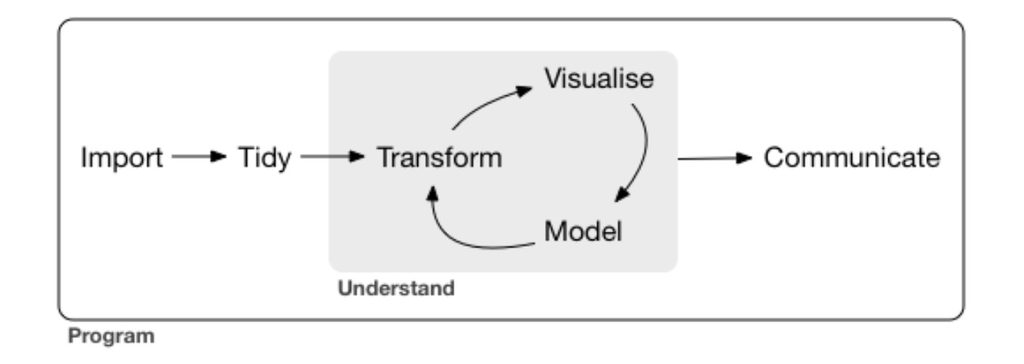

## Processus d'analyse des données

Chaque élément est associé à un `package` donné.

**1. Importer** (**readr**) **2. Transformation des données (data wrangling)** - Arranger (**tidyr**) - Transformer (**dplyr**) 3. Analyse des donnés - Visualisation (**ggplot2**) - Modélisation 4. Communication (**rmarkdown**: ceci n'est pas un package de tidyverse)

PS. Intéressant sur data wrangling https://www.lemagit.fr/conseil/Quest-ce-que-le-Data-Wrangling

## Processus d'analyse des données

- Les autres packages de tidyverse
  - **sringr** : pour travailler avec les données caractères
  - **forcat** : pour travailler avec les facteurs : http://perso.ens-lyon.fr/lise.vaudor/manipulation-de-facteurs-avec-forcats/
  - **purrr** : pour travailler avec les fonctions
  - **tibble** : transformer les données en tribble.

La documentation est éparse sur chacun de ces packages.

## Différences dans les codes

|  | Base r | Tidyverse |
| --- | --- | --- |
|  | . (ex. read.csv) | _ (ex. read_csv) |
| pipes | () | %>% |
| Creer variable | () | mutate |
| Position | mean() | summarise |
|  | median() |  |
| Dispersion | var() | summarise |
|  | sd() |  |
| Analyse/groupe |  | group_by |
| graphique | hist | ggplot |

## 1. Sélection des variables

Voir Séance 2.2

## 2. Sélection des observations

Séance 2.2

## 3. Créations de nouvelles variables

- Variables quantitatives
- Variables factorielles

Séance 2.2

# 3. Exploration des données

## 1. Variables factorielles

- Tableau de fréquences

Voir Séance 2.3

## 2. Variables quantitatives

- Paramètres de tendances centrales
- Paramètres de dispersion

Voir Séance 2.3

## 3. Relations entre deux variables

Voir Séance 2.3